# Bovine Therapeutic Outcomes

Are they really needed? How do we calculate them?

## [2] Picking up where Mike left off

Mike just showed us:

- Monitoring, metrics, standardization
- That a single number — or a **target** — can mislead
- **Granularity matters** (his 2×2)

> When a measure becomes a target, it ceases to be a good measure.

— Goodhart / Strathern

Same *use* level splits into good **and** bad — you can’t tell which without context.

## [3] Step 1 — to measure use, we needed disease context

Regimens became our favored AMU metric — a **well-defined relationship to disease and to reality** (dose × duration × indication).

Total Regimens = Disease Incidence × Regimens per case

- **The importance of capturing disease data** — you can’t read use without it
- What changes when disease incidence goes from *diagnosed* → *anticipated*?

Building on M. Apley’s regimen decomposition · Schrag et al., dairy AMU quantification, Part 1 (2020)

## [4] Step 2 — but the real question is

Did the drug work?

Measuring use was the *means*. The **therapeutic outcome** is the end — and the only thing that tells us whether a treatment earned its place.

## [5] How we define an outcome

[figure not shown]

This is exactly what the **ICASA_Disease** app computes — you set the 7-day and 30-day windows yourself. · Schrag et al. 2022

## [6] We’re not alone — this is where the science is going

**Human medicine**

microbiological cure → composite endpoint → **DOOR**

One ordinal rank for the *whole* clinical course — best = **alive, no complications**; worst = **death** — combining efficacy **and** harms. *“Moving beyond mortality.”*

**Cattle**

clinical & bacteriological cure · FTS · case-fatality · relapse · chronic

mastitis review *“What is success?”* — bacteriological cure ranges **27–95%** across studies and doesn’t predict clinical outcome.

Both fields converged on the same answer: **multi-dimensional, whole-course outcomes** — because a single endpoint distorts.

DOOR endpoint — *“Moving Beyond Mortality,”* Clin Infect Dis 2024; first proposed by Evans et al. 2015. Mastitis review 2021.

## [7] Where DOOR came from

Paper 1 · Evans et al. 2015

**The problem they named**

- Competing risks **distort** use metrics — days-of-therapy falls if the patient dies
- Benefits and harms analyzed **separately**, so no patient is ever seen whole
- Non-inferiority designs reward **blurring** the difference

**The fix: rank the whole course**

- **DOOR** — every participant gets one ordinal rank for their entire clinical experience
- **RADAR** — DOOR for use strategies: rank on outcome first, then break ties by *shorter* antibiotic duration

Their generic 5-level overall clinical outcome — mutually exclusive, ordered by desirability.

**For us:** *“Outcomes are used to analyze patients, rather than using patients to analyze outcomes.”* Success / Relapse / Sold / Died is the same move — one ordered verdict per animal.

Evans SR, Rubin D, Follmann D, et al. *Clin Infect Dis* 2015;61(5):800–6

## [8] The correction — and why I like it

Paper 2 · the erratum, 2023

**For us:** the corrected interval **crosses 50%** — with 26 patients, the honest answer was *“we can’t tell yet.”* Small denominators earn wide intervals. One more reason to read the **trend**, not the point estimate.

Correction to Evans et al. *Clin Infect Dis* 2023;76(1):182 — interval re-estimated by the method of Halperin et al.

## [9] DOOR in the wild — two pneumonia trials

Paper 3 · Howard-Anderson et al. 2024

A multidisciplinary task force — clinicians, FDA, NIH, industry, **and patient advocates** — built a pneumonia DOOR (rank 1 = *alive, no events*; ranks 2–4 = alive with 1, 2, 3 events; rank 5 = *death*), then re-analyzed two completed RCTs.

ZEPHyR n = 448

vancomycin vs linezolid · MRSA pneumonia

DOOR probability **50.2%** (45.1–55.3)

VITAL n = 718

linezolid vs tedizolid · ventilated pneumonia

DOOR probability **48.7%** (44.8–52.6)

Both headlines say **“no difference.”** Decompose VITAL and the drugs are **not** the same: tedizolid did **worse on clinical response** (46.3%) and **better on adverse events** (52.3%). The two moved in opposite directions and cancelled — into one flat number.

Howard-Anderson J, et al. *Moving Beyond Mortality.* Clin Infect Dis 2024;78(2):259–68

## [10] Who decides how bad “bad” is?

Discussion · from Paper 3

DOOR’s **partial credit** analysis scores the ranks like a test: best = **100**, death = **0**, and the middle ranks are worth *whatever you think they’re worth* — as long as the order holds. Two people can score the same trial differently and **both be right**.

[figure not shown]

**Discussion for this room:** on *your* operation — is one relapse a 90 or a 30? Is a sale at day 20 nearer success or nearer death? The statistics can’t answer that. **You do.**

Partial credit analysis — Howard-Anderson et al. 2024. Illustrative scores.

## [11] The core insight: a single number lies

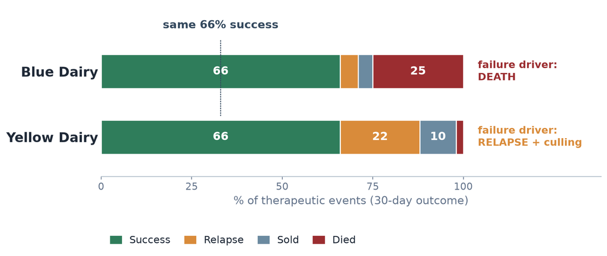

Same **66% success** — opposite stories. **Death** is unambiguously bad; **relapse/aggressive retreatment** is ambiguous and warrants a look.

## [12] The retreatment nuance is real science

**Post-Treatment Interval (PTI)**

- Make animals eligible to re-treat at **3 days** → retreatment rates jump
- The “failure” is partly an **artifact of measuring too soon**
- Retreatment drug-*switching* is linked to **more resistant** isolates

So: investigate the *trend* — don’t just read the number.

## [13] They named our problem in 2015

Discussion · from Paper 1

> Patients may switch therapy because of clinical failure but should not necessarily be considered a clinical failure **because they switch therapy.**

— Evans et al. 2015, on constructing an overall clinical outcome

**Their warning**

- Some endpoints are partly a **clinician decision**, not purely a patient outcome
- That adds a **second source of variation** — the person, not the disease
- Their fix: prefer outcomes that are *“a function of the patient,”* or **standardize the decision criteria**

**Our version, word for word**

- **Relapse** is a retreatment — and a retreatment is a *person* deciding
- Change the eligibility window and the “failure” rate moves, with no animal changing at all
- So: **fix the window** (that’s the 7 / 30-day setting), then read the trend

Human-medicine statisticians wrote down our PTI problem eleven years ago. **Relapse measures the protocol as much as the animal** — which is exactly why it’s the category to *investigate*, not to police.

## [14] Context changed the answer

Discussion · from Paper 3

Same VITAL trial, same two drugs, sliced by **kidney function** — and the recommendation flips depending on the patient in front of you.

Best kidney function (CrCl ≥ 90)

← favors linezolid

Moderately reduced (CrCl < 60)

trend → tedizolid

Worst kidney function (CrCl < 15)

→ favors tedizolid

**And they said so themselves:** few patients, many subgroups — *“should be interpreted with caution, viewed as hypothesis generating.”*

**That caution *is* the discipline.** Context tells you which question to ask. It never hands you a target.

Subgroup analysis — Howard-Anderson et al. 2024, Figure 4 (intervals there)

## [15] Why trends, within farm context, are the only path to action

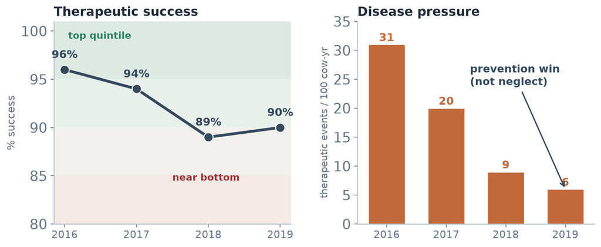

Red Dairy metritis: success **96% → 89%** looks tiny — but it moved from the **top quintile to near the bottom**, while disease pressure **collapsed 31 → 6**. A prevention win, not neglect. Context + trend → ask *“why is…?”*, not *“above or below target.”*

## [16] The stewardship payoff

Effective → use it. Not effective → don’t.

↑

therapeutic success

↓

morbidity

↓

mortality

All anchored in **animal welfare** — the obligation that makes the decision for us.

Echoing M. Apley — stewardship must never mean withholding an effective treatment

## [17] The engine: the ICASA pipeline & three apps

[figure not shown]

**Use** (FeedlotMetrics) → **Outcome** (Disease — where we are) → **Value** (Econ). Each gives the others meaning.

## [18] Where resistance fits

- Bruce is right: **progress-over-time has been badly under-measured** — ARGs and wastewater are a real frontier
- But resistance tells you a **state**; outcomes tell you **what to do**
- Metaphylaxis study: use ↑, health ↑ (BRD **17% vs 40%**), resistance **not** selected — yet other studies disagree

Outcomes tell us what to do *when the resistance science is still uncertain.*

Credille et al. 2024

## [19] Take this with you

Papers · tools · apps

**The DOOR papers**

1. Evans SR, et al. *Desirability of Outcome Ranking (DOOR) and Response Adjusted for Duration of Antibiotic Risk (RADAR).*  
   Clin Infect Dis 2015;61(5):800–6 · PMC4542892
2. *Correction.* Clin Infect Dis 2023;76(1):182  
   the CI, re-estimated
3. Howard-Anderson J, et al. *Moving Beyond Mortality: … DOOR Endpoint for HABP/VABP.*  
   Clin Infect Dis 2024;78(2):259–68 · PMC10874265 free

**Run a DOOR analysis yourself**

methods.bsc.gwu.edu  
free web app · from the ARLG

**See it in cattle**

**ICASA_Disease** — outcomes  
you set the 7- and 30-day windows  
ICASAProject site → Therapeutic Outcomes

Papers 1 and 3 are the argument; the correction is the humility. All three are in the meeting folder.

## [20]

The one thing

Trend outcomes over time, within farm context — the only way to drive data-driven, welfare-anchored action.

## [21] Why we do this

Where this started

- Respect for the **power of effective antimicrobials**
- A drive to keep them working — for the animals that need them
- Stewardship = **protecting efficacy**, not just cutting use

> If antimicrobial stewardship is perceived as *not treating a diseased animal when an antimicrobial would be effective*, we are probably done.

— M. Apley, *Monitoring our way to stewardship?*